# Data transformation

# Describing data (AKA univariate statistics)

**Univariate statistics** is a term for statistics that describes a numerical and continuous variable. We will be describing the data along the following parameters:

- distribution (skewness and kurtosis)
- central tendency (mean and median)
- dispersion

## Distribution

Lets just imagine we want to summarise the life expectancy of people across the world. Using the gapminder [https://www.gapminder.org/] dataset that is freely available about the world, we can look at the distribution of life expectancies across countries in 2007:

```r
# install (if required) and load the gapminder data
if(!require(gapminder)){install.packages("gapminder")}
library(gapminder)

# create a new data frame that only focuses on data from 2007
gapminder_2007 <- subset(
  gapminder,   # the data set
  year == 2007
)

# lets have a look at the data
gapminder_2007
```

```
## # A tibble: 142 × 6
##    country     continent  year lifeExp       pop gdpPercap
##    <fct>       <fct>     <int>   <dbl>     <int>     <dbl>
##  1 Afghanistan Asia       2007    43.8  31889923      975.
##  2 Albania     Europe     2007    76.4   3600523     5937.
##  3 Algeria     Africa     2007    72.3  33333216     6223.
##  4 Angola      Africa     2007    42.7  12420476     4797.
##  5 Argentina   Americas   2007    75.3  40301927    12779.
##  6 Australia   Oceania    2007    81.2  20434176    34435.
##  7 Austria     Europe     2007    79.8   8199783    36126.
##  8 Bahrain     Asia       2007    75.6    708573    29796.
##  9 Bangladesh  Asia       2007    64.1 150448339     1391.
## 10 Belgium     Europe     2007    79.4  10392226    33693.
## # … with 132 more rows
## # ℹ Use `print(n = ...)` to see more rows
```

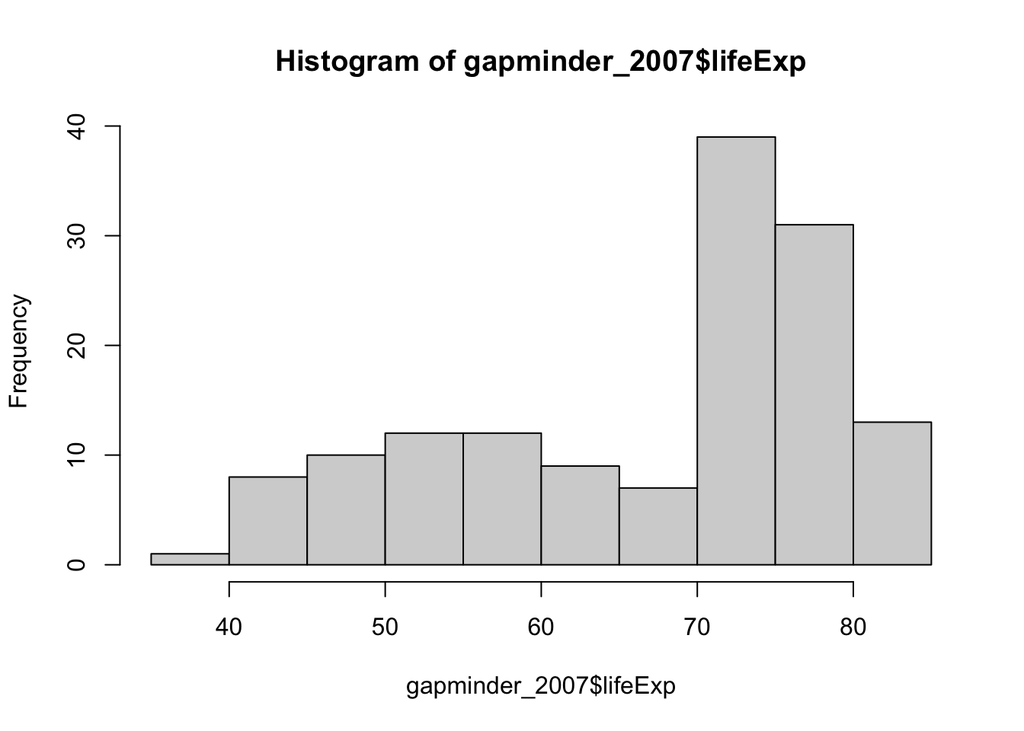

```r
# and now plot a histogram of the life expectancy data to see the distribution
hist(gapminder_2007$lifeExp)
```

So whilst this histogram visualises the distribution of the data, it’s helpful to be able to **statistically quantify** (i.e. give numbers that represent) this distribution. Remember that for many statistical tests (parmatric) it’s helpful to have data that is **normally distributed**. Normally distributed data (also known as **Gaussian distributions** and associated with **parametric statistics**) generally looks like a bell curve:

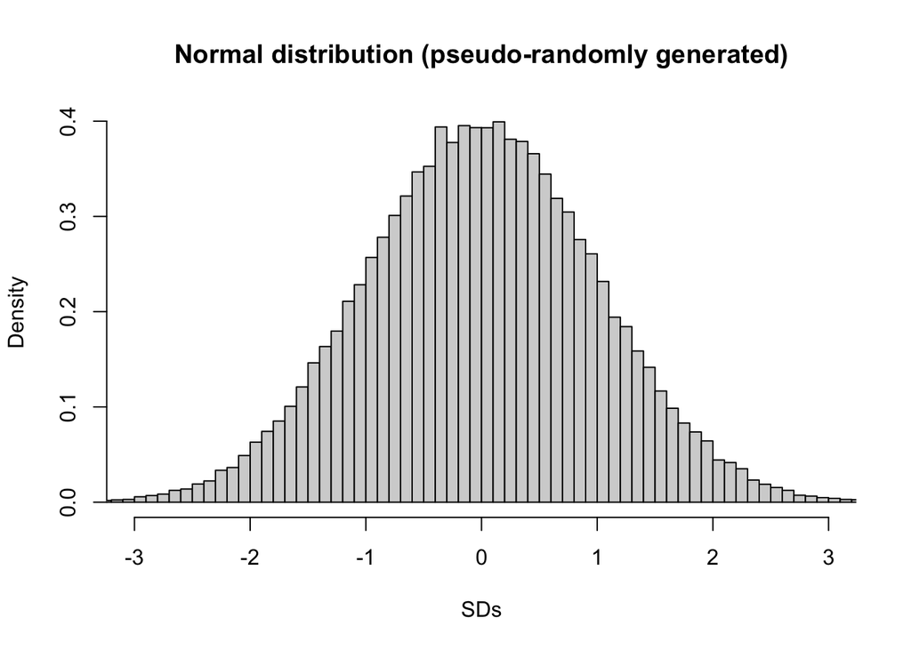

```r
# generating random data to fit a normal distribution.
norm_data <-rnorm(
  100000,               # the number of samples
  mean=0,               # the mean (which in this case should be almost identical to the median)
  sd=1                  # the standard deviation
)
hist(
  norm_data,
  breaks = 100,           # the number of bins (the more bins there are, the thinner each bin is)
  xlim   = c(-3,3),       # the range of the x-axis
  freq   = FALSE,         # changes the y-axis from reporting the absolute frequency to reporting the relative density
  xlab   = "SDs",
  main   = "Normal distribution (pseudo-randomly generated)"
)
```

- skewness
- kurtosis

### Skewness

Data can be negatively skewed, where the mean is less than the median:

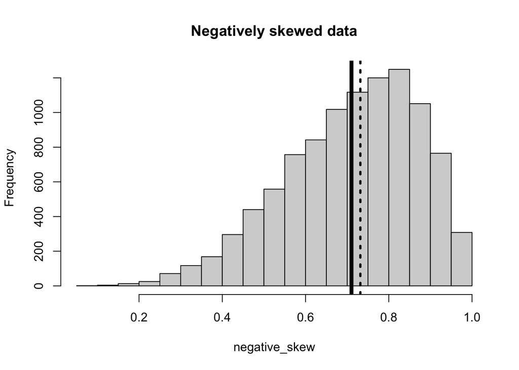

```r
# Skewed to the right
negative_skew = rbeta(10000,5,2)
hist(negative_skew, main = "Negatively skewed data")
abline(
  v=mean(negative_skew),  # where the line for the mean will be
  lwd=5
)
abline(
  v=median(negative_skew),
  lwd=3,
  lty=3
)
```

*The thick lines represents the mean; the dashed lines represents the median. The bigger the distance between these, the less normally distributed your data is. (see* **central tendancy** *below)*

Or positively skewed, where the median is less than the mean:

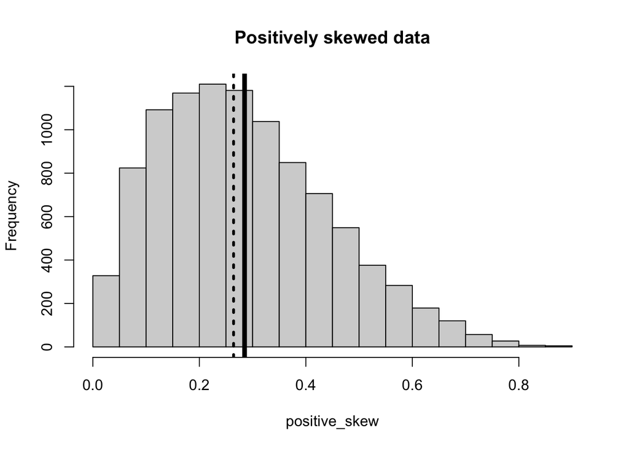

```r
# Skewed to the left
positive_skew = rbeta(10000,2,5)
hist(positive_skew, main="Positively skewed data")
abline(
  v=mean(positive_skew),  # where the line for the mean will be
  lwd=5
)
abline(
  v=median(positive_skew), # where the line for the median will be
  lwd=3,
  lty=3
)
```

*The thick lines represents the mean; the dashed lines represents the median. The bigger the distance between these, the less normally distributed your data is. (see central tendancy below)*

So now that we know what skewed distributions look like, we now need to **quantify** how much of a problem with skewness there is. If we add together the amount of skewness for each data point together and then divide by a general summary of the total standard deviation, then you get an estimate of skewness. The next section is a breakdown of the formula for those interested in it (but this is *not crucial*), but **the key point point is that outliers skew the data, and so outliers that are larger than the mean positively skew the data, and outliers below the mean negatively skew it. If there are an equal number of outliers on either side of the mean then the data will not be skewed.**

#### Optional

If we want to manually calculate skewness:

$$\tilde{\mu_{3}} = \sum((\frac{x_i- \bar{x}{}} {\sigma} )^3) *
\frac{N}{(N-1) * (N-2)}$$
To do this in R you *could* calculate it manually

```r
# applying this to the positive skew data above
positive_skew_n = length(positive_skew)
positive_skewness = sum(((positive_skew - mean(positive_skew))/sd(positive_skew))^3) * (
  positive_skew_n / ((positive_skew_n-1) * (positive_skew_n - 2))
)
# to show the output:
positive_skewness
```

```
## [1] 0.5822644
```

… or just

use code from https://stackoverflow.com/a/54369572 to give you values for skewness (this has been chosen as this gives skewness and its standard error as calculated by major software like SPSS and JASP):

```r
# Skewness and kurtosis and their standard errors as implement by SPSS
#
# Reference: pp 451-452 of
# http://support.spss.com/ProductsExt/SPSS/Documentation/Manuals/16.0/SPSS 16.0 Algorithms.pdf
#
# See also: Suggestion for Using Powerful and Informative Tests of Normality,
# Ralph B. D'Agostino, Albert Belanger, Ralph B. D'Agostino, Jr.,
# The American Statistician, Vol. 44, No. 4 (Nov., 1990), pp. 316-321

spssSkewKurtosis=function(x) {
  w=length(x)
  m1=mean(x)
  m2=sum((x-m1)^2)
  m3=sum((x-m1)^3)
  m4=sum((x-m1)^4)
  s1=sd(x)
  skew=w*m3/(w-1)/(w-2)/s1^3
  sdskew=sqrt( 6*w*(w-1) / ((w-2)*(w+1)*(w+3)) )
  kurtosis=(w*(w+1)*m4 - 3*m2^2*(w-1)) / ((w-1)*(w-2)*(w-3)*s1^4)
  sdkurtosis=sqrt( 4*(w^2-1) * sdskew^2 / ((w-3)*(w+5)) )
  mat=matrix(c(skew,kurtosis, sdskew,sdkurtosis), 2,
        dimnames=list(c("skew","kurtosis"), c("estimate","se")))
  return(mat)
}
spssSkewKurtosis(positive_skew)
```

```
##            estimate         se
## skew      0.5822644 0.02449122
## kurtosis -0.1344341 0.04897755
```

However, this value is not very meaningful by itself to confirm whether there’s a significant problem with skewness. To address this, lets use the skewness standard error (see above), to calculate a **z-score**. **Z-scores** can capture how *significant* a value is, i.e. how unlikely the number is considering what you would normally expect. In this case, when you divide skewness by standard error, you get a z-score, and if the **absolute value** (i.e. ignoring whether it is positive or negative) of the z-score is greater than 1.96 then it is significantly skewed.

#### Optional

##### Why is 1.96 (sometimes) the threshold for “significance” with z-values?

**Parametric statistics** often compare values to a **normal** distribution of **expected results**, based on the **estimated mean and SD**. For example, lets imagine that a man called John thinks he’s either unusually tall, or unusally short, but he isn’t sure which. He could compare his height to a normal distribution of heights, and see whether he’s in the top or bottom 2.5%.

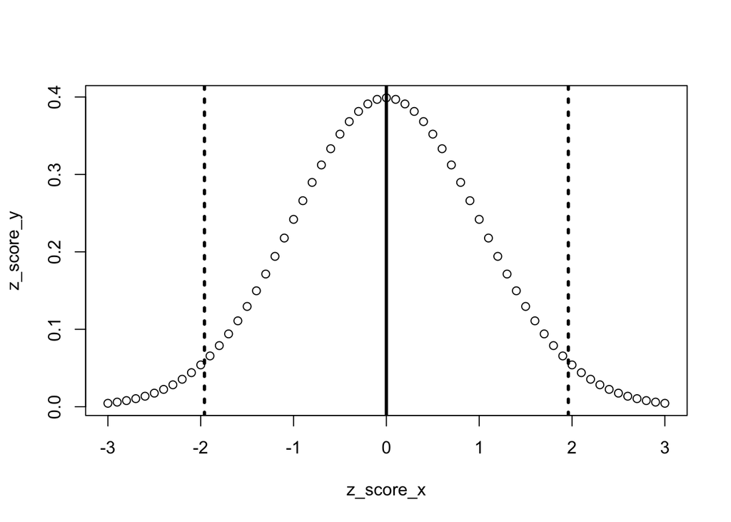

```r
# Plot a normal distribution of heights
z_score_x <- seq(
  -3,    # min
  3,    # max
  by = .1
)
z_score_y <- dnorm(
  z_score_x,
  mean = 0,
  sd   = 1
)
plot(
  z_score_x,
  z_score_y
)
# Add line to show mean
abline(
  v=0,  # where the line for the mean will be
  lwd=3
)
# Add line to show lower threshold
abline(
  v= -1.96,
  lwd=3,
  lty=3
)
# Add line to show higher threshold
abline(
  v= 1.96,
  lwd=3,
  lty=3
)
```